# Crime Data Mapping Using R Spatial

Tutorial on reading in data and creating some basic maps in the simple features package. The first step here is to load in some packages.

```r
library(sf)
library(dplyr)
library(readr)
library(ggplot2)
library(mapview)
library(raster)
library(lubridate)
# set directory from which we read in data
ddir <- "C:/Users/Yixin Sun/Documents/Dropbox/Recruiting/2018 Recruiting/epic_orientation/data/Spatial_Exercise"
# function that creates custom map style for ggplot
theme_nothing <- function(base_size = 12, title_size = 15){
  return(
    theme(panel.grid.major = element_line(colour = "transparent"),
          panel.grid.minor = element_line(colour = "transparent"),
          panel.background = element_blank(), axis.line = element_blank(),
          axis.text.x = element_blank(),
          axis.text.y = element_blank(),
          axis.title = element_blank(),
          axis.ticks = element_blank(),
          plot.title = element_text(size = title_size, hjust = 0.5),
          plot.caption = element_text(size = 6)))
}
```

# Converting CSV to `sf` Object

Often times with point objects, the data comes in a table of latitude and longitude, which we coerce into a spatial object. The important thing here is to know which coordinate reference system we are using.

```r
utm_crs <- 27700

# load data in and get rid of spaces in column names
streetCrime <-
  read_csv(file.path(ddir, "2012-03-cumbria-street.csv")) %>%
  rename(Report_by = `Reported by`,
         Falls_within = `Falls within`,
         Crime_type = `Crime type`)
glimpse(streetCrime)

streetCrime <-
  streetCrime %>%
  st_as_sf(coords = c("Easting", "Northing"), crs = utm_crs)

glimpse(streetCrime)
```

[output not shown]

# Exploratory Plotting

There are several ways to visualize data - base R, `mapview`, or `ggplot2`. Since `mapview` will overlay your data on a global map, it is a good way to visualize if you have the right coordinate reference system.

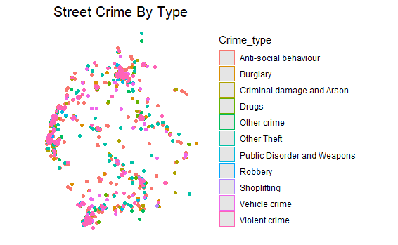

# Police Neighbourhood Areas

UK Crime is organized by neighborhoods. Here, we read in the shapefile of the neighborhoods and aggregate the point data to the neighborhood level. Important to note that the neighborhood polygons are in longitude/latitude while the crime data is in UTM, so we must first convert the data to the same CRS

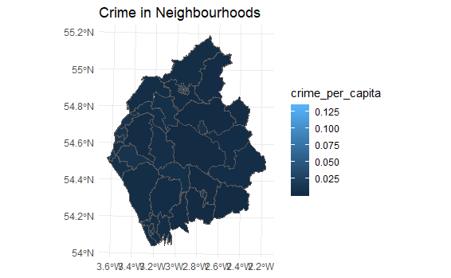

# Land Use Raster Data

Some neighbourhoods are clearly more rural than others. Therefore, it might be useful to visualize the land types the analysis region. Here, we learn how to read in and extract information from a raster file.

Raster files store information for each pixel. In this case, we have a land use classification at each pixel level. What we want to do is for each neighbourhood polygon, count up the number of pixels in that polygon that fall within each land use classification.

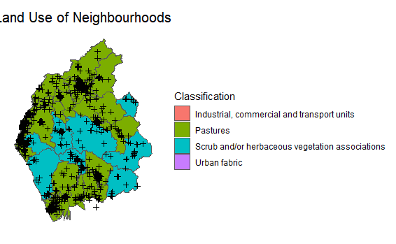

# Crimes and Roads

Here we are interested in whether crimes are close to major roads, or if there are specific crimes that usually happen near roads. We load in road data, and find distance of crimes to roads.

```r
roads <-
  file.path(ddir, "mainroads.shp") %>%
  st_read(stringsAsFactors = F) %>%
  st_transform(utm_crs)

table(roads$type)

# keep just major roads
roads <-
  roads %>%
  filter(type %in% c("motorway", "motorway_link", "trunk", "trunk_link",
                     "primary", "primary_link"))

# Get distance to closest main road
streetCrime$dRoad <-
  st_distance(streetCrime, roads) %>%
  apply(1, min)


streetCrime %>%
  ggplot(aes(x = Crime_type, y = dRoad))
```

[output not shown]

# Crime over Time

We also have a data file of the crime counts in neighbourhoods for a number of month. The file has one for each month for each neighbourhood, and lists the number of crimes in each category. Here, we first join this with the neighbourhoods polygons and create some time series plots

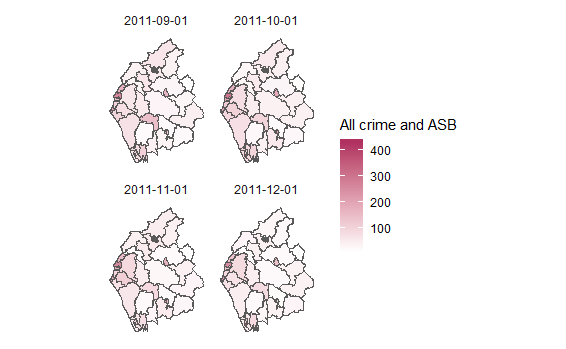

# Independent tasks

- Chloropleth map of all the violent crimes in each neighbourhood using all the data from `allCrime`
- Use two methods, mapping and line graph, to visualize how crime patterns have changed over time for just neighbourhoods GARZ01, GARZ02, GARZ03, GARZ04, and GARZ05
- Repeat exercise with roads, except this time, using bodies of water. The water shapefile path should be `file.path(ddir, "naturalwater.shp")`.